# Proyecto_Final_Modelos_Lineales

2026-06-29

## 1. Descripción de los datos

En esta sección realizamos la carga del dataset e inspeccionamos sus características generales. Además, añadimos una varable sobre el sexo para simplificar el análisis posterior.

```r
library(ggplot2)
library(corrplot)
library(car)
data <- read.csv("CrabAgePrediction.csv")

data$Sex.Det <- ifelse(data$Sex == "I", "I", "D")

summary(data)
```

```
##      Sex                Length          Diameter          Height
##  Length:3893        Min.   :0.1875   Min.   :0.1375   Min.   :0.0000
##  Class :character   1st Qu.:1.1250   1st Qu.:0.8750   1st Qu.:0.2875
##  Mode  :character   Median :1.3625   Median :1.0625   Median :0.3625
##                     Mean   :1.3113   Mean   :1.0209   Mean   :0.3494
##                     3rd Qu.:1.5375   3rd Qu.:1.2000   3rd Qu.:0.4125
##                     Max.   :2.0375   Max.   :1.6250   Max.   :2.8250
##      Weight        Shucked.Weight     Viscera.Weight      Shell.Weight
##  Min.   : 0.0567   Min.   : 0.02835   Min.   : 0.01418   Min.   : 0.04252
##  1st Qu.:12.6722   1st Qu.: 5.34388   1st Qu.: 2.66485   1st Qu.: 3.71378
##  Median :22.7930   Median : 9.53961   Median : 4.86194   Median : 6.66213
##  Mean   :23.5673   Mean   :10.20734   Mean   : 5.13655   Mean   : 6.79584
##  3rd Qu.:32.7862   3rd Qu.:14.27397   3rd Qu.: 7.20077   3rd Qu.: 9.35534
##  Max.   :80.1015   Max.   :42.18406   Max.   :21.54562   Max.   :28.49125
##       Age           Sex.Det
##  Min.   : 1.000   Length:3893
##  1st Qu.: 8.000   Class :character
##  Median :10.000   Mode  :character
##  Mean   : 9.955
##  3rd Qu.:11.000
##  Max.   :29.000
```

### Análisis Exploratorio Visual

Para entender cómo se distribuye la edad de los cangrejos según su sexo y la nueva categorización simplificada, observamos los siguientes gráficos de caja:

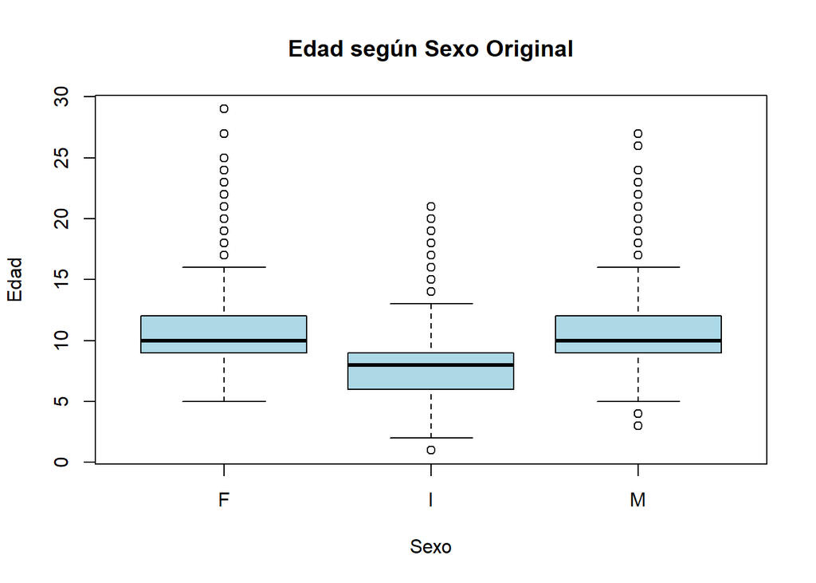

```r
boxplot(data$Age ~ data$Sex, main = "Edad según Sexo Original",
        xlab = "Sexo", ylab = "Edad", col = "lightblue")
```

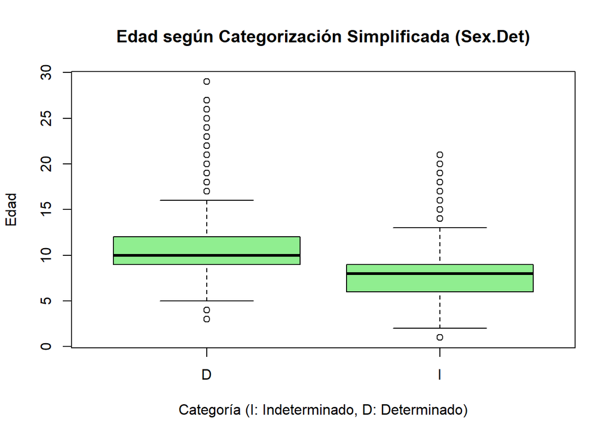

```r
boxplot(data$Age ~ data$Sex.Det, main = "Edad según Categorización Simplificada (Sex.Det)",
        xlab = "Categoría (I: Indeterminado, D: Determinado)", ylab = "Edad", col = "lightgreen")
```

A continuación, analizamos la relación lineal individual de cada variable continua con la edad mediante gráficos de dispersión.

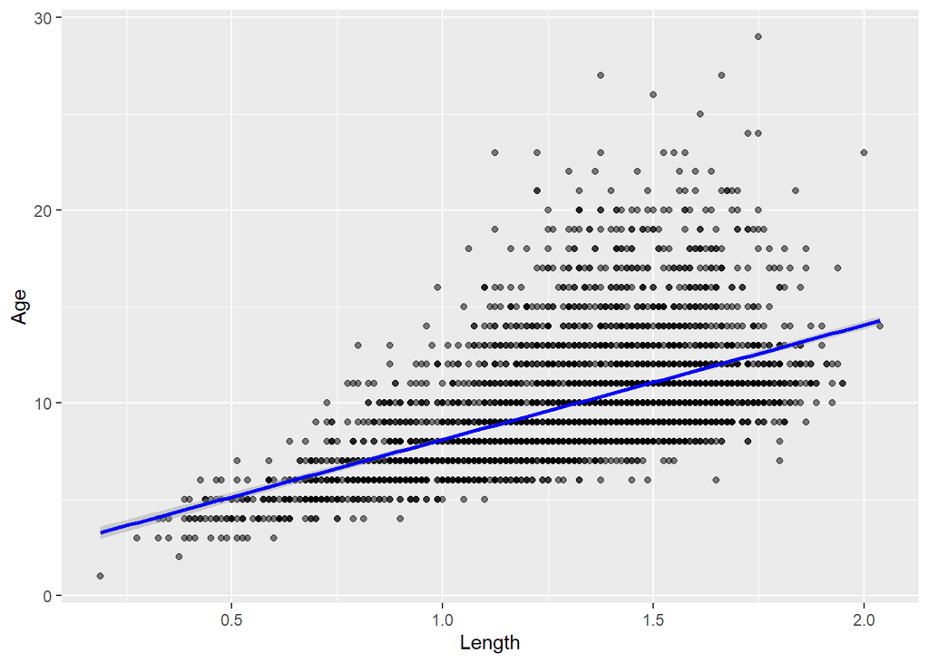

```r
ggplot(data, aes(x = Length, y = Age)) +
  geom_point(alpha = 0.5) +
  geom_smooth(method = "lm", se = TRUE, color = "blue")
```

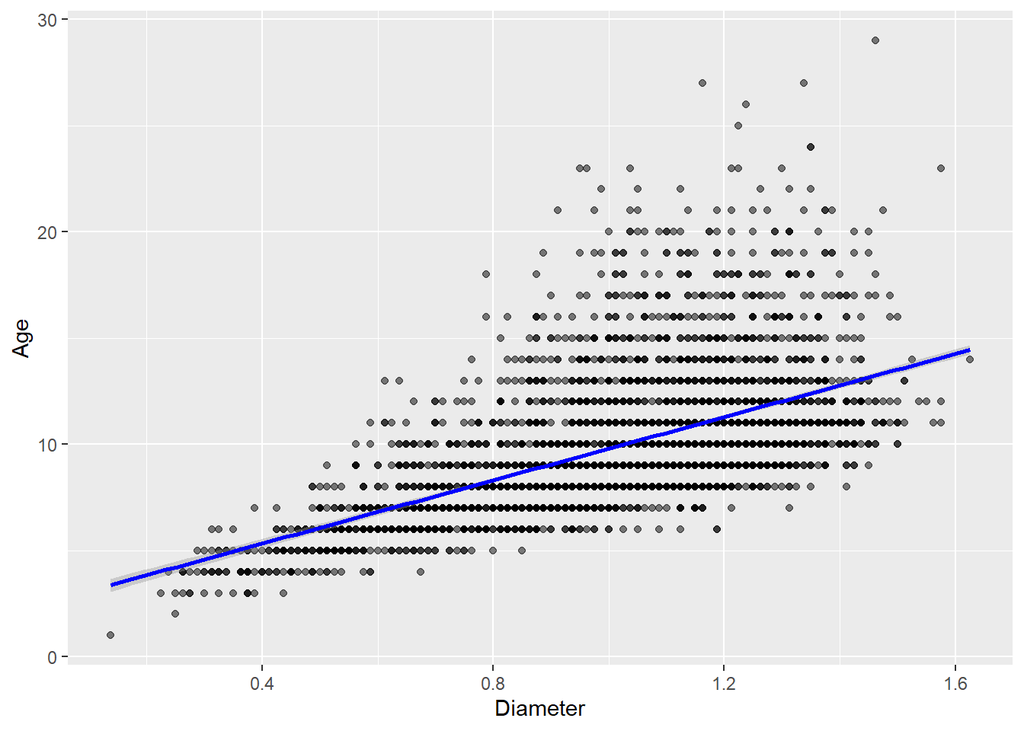

```r
ggplot(data, aes(x = Diameter, y = Age)) +
  geom_point(alpha = 0.5) +
  geom_smooth(method = "lm", se = TRUE, color = "blue")
```

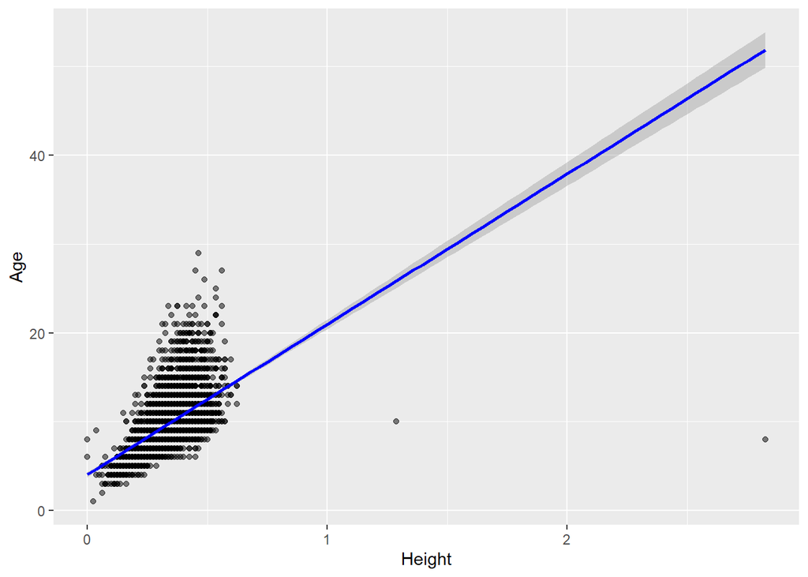

```r
ggplot(data, aes(x = Height, y = Age)) +
  geom_point(alpha = 0.5) +
  geom_smooth(method = "lm", se = TRUE, color = "blue")
```

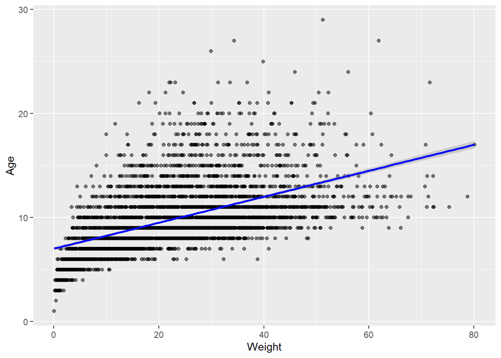

```r
ggplot(data, aes(x = Weight, y = Age)) +
  geom_point(alpha = 0.5) +
  geom_smooth(method = "lm", se = TRUE, color = "blue")
```

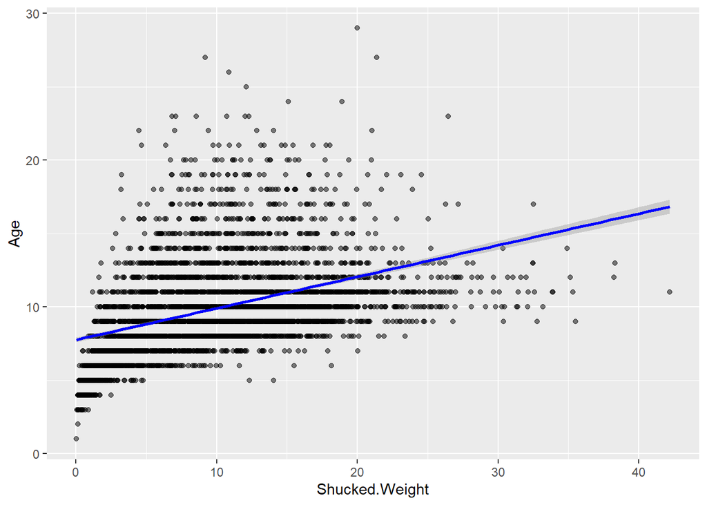

```r
ggplot(data, aes(x = Shucked.Weight, y = Age)) +
  geom_point(alpha = 0.5) +
  geom_smooth(method = "lm", se = TRUE, color = "blue")
```

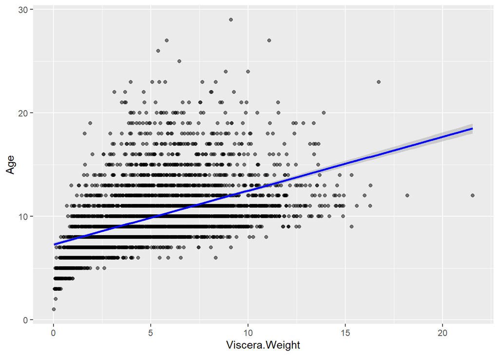

```r
ggplot(data, aes(x = Viscera.Weight, y = Age)) +
  geom_point(alpha = 0.5) +
  geom_smooth(method = "lm", se = TRUE, color = "blue")
```

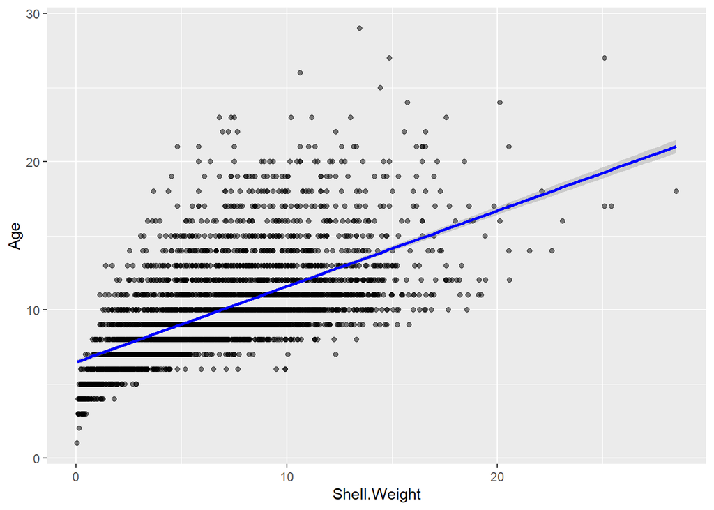

```r
ggplot(data, aes(x = Shell.Weight, y = Age)) +
  geom_point(alpha = 0.5) +
  geom_smooth(method = "lm", se = TRUE, color = "blue")
```

### Diagnóstico de Multicolinealidad Inicial

Dada la naturaleza morfológica de los datos, evaluamos la correlación lineal existente entre todas las características numéricas del cangrejo mediante una matriz de correlación, justificando así la necesidad de implementar métodos de selección de variables.

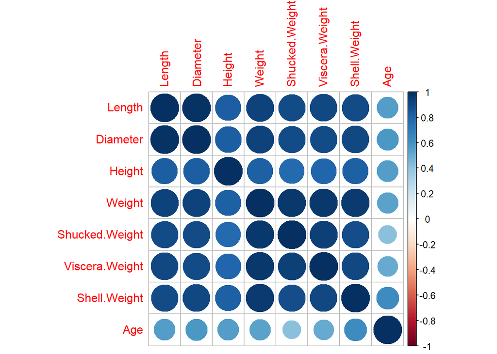

```r
matriz_corr <- cor(data[, sapply(data, is.numeric)], use = "pairwise.complete.obs")
corrplot(matriz_corr, method = "circle")
```

## 2. Selección de variables

Para resolver los problemas de alta multicolinealidad observados en el análisis exploratorio, implementamos una regularización Lasso empleando validación cruzada. Comparamos los coeficientes obtenidos al incluir todas las variables frente a un esquema que excluye la variable de sexo original para evaluar el impacto de la recodificación.

```r
library(glmnet)
# Matriz de diseño con todas las variables originales
X1 <- model.matrix(Age ~ ., data = data)[, -1]
y <- data$Age

# Matriz de diseño excluyendo la variable Sex original (usando solo Sex.Det)
X2 <- model.matrix(Age ~ . - Sex, data = data)[, -1]

# Ajuste de modelos Lasso mediante validación cruzada
lasso1 <- cv.glmnet(X1, y, alpha = 1)
lasso2 <- cv.glmnet(X2, y, alpha = 1)

# Extracción de coeficientes estimados óptimos
coef_lasso1 <- coef(lasso1)
coef_lasso2 <- coef(lasso2)

print(coef_lasso1)
```

```
## 11 x 1 sparse Matrix of class "dgCMatrix"
##                         s1
## (Intercept)     4.80046544
## SexI           -0.81527302
## SexM            .
## Length          .
## Diameter        2.92864009
## Height          3.77816049
## Weight          .
## Shucked.Weight -0.29603656
## Viscera.Weight  .
## Shell.Weight    0.60774018
## Sex.DetI       -0.01780834
```

```r
print(coef_lasso2)
```

```
## 9 x 1 sparse Matrix of class "dgCMatrix"
##                         s1
## (Intercept)     4.31224530
## Length          .
## Diameter        3.66149197
## Height          3.92835808
## Weight          0.04355676
## Shucked.Weight -0.41362095
## Viscera.Weight  .
## Shell.Weight    0.58867417
## Sex.DetI       -0.86193615
```

### Comparación de Modelos e Inspección de VIF

A partir de los resultados de Lasso, comparamos el rendimiento analítico del modelo completo (excluyendo la variable categórica redundante) frente al modelo simplificado propuesto por la selección de variables. Evaluamos el Factor de Inflación de la Varianza (VIF) para comprobar la reducción de la colinealidad.

```r
# Ajuste de los modelos lineales basados en las selecciones previas
modelo_todas_las_variables <- lm(Age ~ . - Sex, data = data)
modelo_segun_lasso <- lm(Age ~ Diameter + Sex.Det + Height + Shucked.Weight + Shell.Weight, data = data)

summary(modelo_todas_las_variables)
```

```
##
## Call:
## lm(formula = Age ~ . - Sex, data = data)
##
## Residuals:
##      Min       1Q   Median       3Q      Max
## -10.0120  -1.3042  -0.3337   0.8546  13.9123
##
## Coefficients:
##                Estimate Std. Error t value Pr(>|t|)
## (Intercept)     3.95541    0.29483  13.416  < 2e-16 ***
## Length         -0.42930    0.74519  -0.576    0.565
## Diameter        4.84963    0.91851   5.280 1.36e-07 ***
## Height          4.09652    0.62514   6.553 6.38e-11 ***
## Weight          0.31710    0.02618  12.114  < 2e-16 ***
## Shucked.Weight -0.69921    0.02955 -23.661  < 2e-16 ***
## Viscera.Weight -0.36921    0.04683  -7.884 4.09e-15 ***
## Shell.Weight    0.29683    0.04092   7.254 4.87e-13 ***
## Sex.DetI       -0.87393    0.09312  -9.385  < 2e-16 ***
## ---
## Signif. codes:  0 '***' 0.001 '**' 0.01 '*' 0.05 '.' 0.1 ' ' 1
##
## Residual standard error: 2.195 on 3884 degrees of freedom
## Multiple R-squared:  0.5365, Adjusted R-squared:  0.5355
## F-statistic: 561.9 on 8 and 3884 DF,  p-value: < 2.2e-16
```

```r
summary(modelo_segun_lasso)
```

```
##
## Call:
## lm(formula = Age ~ Diameter + Sex.Det + Height + Shucked.Weight +
##     Shell.Weight, data = data)
##
## Residuals:
##      Min       1Q   Median       3Q      Max
## -10.1965  -1.3316  -0.3351   0.8544  15.7748
##
## Coefficients:
##                Estimate Std. Error t value Pr(>|t|)
## (Intercept)     3.79723    0.28025  13.549  < 2e-16 ***
## Diameter        4.43646    0.41364  10.726  < 2e-16 ***
## Sex.DetI       -0.91586    0.09403  -9.741  < 2e-16 ***
## Height          4.15420    0.63475   6.545 6.74e-11 ***
## Shucked.Weight -0.41150    0.01379 -29.849  < 2e-16 ***
## Shell.Weight    0.68680    0.02392  28.718  < 2e-16 ***
## ---
## Signif. codes:  0 '***' 0.001 '**' 0.01 '*' 0.05 '.' 0.1 ' ' 1
##
## Residual standard error: 2.236 on 3887 degrees of freedom
## Multiple R-squared:  0.5188, Adjusted R-squared:  0.5182
## F-statistic: 838.3 on 5 and 3887 DF,  p-value: < 2.2e-16
```

```r
# Evaluación del Factor de Inflación de la Varianza (VIF)
vif(modelo_todas_las_variables)
```

```
##         Length       Diameter         Height         Weight Shucked.Weight
##      40.481662      41.987383       3.478375     106.796017      27.773769
## Viscera.Weight   Shell.Weight        Sex.Det
##      17.067952      21.031912       1.516041
```

```r
vif(modelo_segun_lasso)
```

```
##       Diameter        Sex.Det         Height Shucked.Weight   Shell.Weight
##       8.209312       1.490147       3.457293       5.827520       6.925415
```

## 3. Inferencia sobre los parámetros

En esta sección analizamos la significación estadística de los coeficientes del modelo seleccionado por Lasso. Evaluamos primero los intervalos de confianza bajo los supuestos clásicos y luego realizamos una prueba de homocedasticidad para determinar si es necesario aplicar correcciones sobre las varianzas de los estimadores.

```r
library(skedastic)
library(sandwich)
library(lmtest)
# Resumen clásico e intervalos de confianza bajo el supuesto de homocedasticidad
summary(modelo_segun_lasso)
```

```
##
## Call:
## lm(formula = Age ~ Diameter + Sex.Det + Height + Shucked.Weight +
##     Shell.Weight, data = data)
##
## Residuals:
##      Min       1Q   Median       3Q      Max
## -10.1965  -1.3316  -0.3351   0.8544  15.7748
##
## Coefficients:
##                Estimate Std. Error t value Pr(>|t|)
## (Intercept)     3.79723    0.28025  13.549  < 2e-16 ***
## Diameter        4.43646    0.41364  10.726  < 2e-16 ***
## Sex.DetI       -0.91586    0.09403  -9.741  < 2e-16 ***
## Height          4.15420    0.63475   6.545 6.74e-11 ***
## Shucked.Weight -0.41150    0.01379 -29.849  < 2e-16 ***
## Shell.Weight    0.68680    0.02392  28.718  < 2e-16 ***
## ---
## Signif. codes:  0 '***' 0.001 '**' 0.01 '*' 0.05 '.' 0.1 ' ' 1
##
## Residual standard error: 2.236 on 3887 degrees of freedom
## Multiple R-squared:  0.5188, Adjusted R-squared:  0.5182
## F-statistic: 838.3 on 5 and 3887 DF,  p-value: < 2.2e-16
```

```r
confint(modelo_segun_lasso)
```

```
##                     2.5 %     97.5 %
## (Intercept)     3.2477812  4.3466878
## Diameter        3.6254980  5.2474281
## Sex.DetI       -1.1002009 -0.7315134
## Height          2.9097299  5.3986719
## Shucked.Weight -0.4385262 -0.3844699
## Shell.Weight    0.6399150  0.7336908
```

```r
# Diagnóstico de Homocedasticidad mediante el test de Breusch-Pagan
breusch_pagan(modelo_segun_lasso)
```

```
## # A tibble: 1 × 5
##   statistic  p.value parameter method                alternative
##       <dbl>    <dbl>     <dbl> <chr>                 <chr>
## 1      376. 5.02e-79         5 Koenker (studentised) greater
```

### Inferencia Robusta ante Heterocedasticidad

Dado el resultado del test de Breusch-Pagan, procedemos a realizar inferencia consistente frente a heterocedasticidad utilizando la corrección HC4 para ajustar las desviaciones típicas de los coeficientes y recalcular los intervalos de confianza.

```r
# Re-testeo de los coeficientes usando la corrección robusta HC4
coef_HC4 <- coeftest(modelo_segun_lasso, vcov = vcovHC(modelo_segun_lasso, type = "HC4"))
print(coef_HC4)
```

```
##
## t test of coefficients:
##
##                 Estimate Std. Error  t value  Pr(>|t|)
## (Intercept)     3.797234   0.672422   5.6471 1.748e-08 ***
## Diameter        4.436463   1.915030   2.3167   0.02057 *
## Sex.DetI       -0.915857   0.109556  -8.3597 < 2.2e-16 ***
## Height          4.154201   8.849014   0.4695   0.63877
## Shucked.Weight -0.411498   0.017398 -23.6524 < 2.2e-16 ***
## Shell.Weight    0.686803   0.090629   7.5782 4.355e-14 ***
## ---
## Signif. codes:  0 '***' 0.001 '**' 0.01 '*' 0.05 '.' 0.1 ' ' 1
```

```r
# Intervalos de confianza robustos HC4
intervalos_HC4 <- coefci(modelo_segun_lasso, vcov = vcovHC(modelo_segun_lasso, type = "HC4"))
print(intervalos_HC4)
```

```
##                      2.5 %     97.5 %
## (Intercept)      2.4789011  5.1155679
## Diameter         0.6819047  8.1910214
## Sex.DetI        -1.1306492 -0.7010650
## Height         -13.1949501 21.5033519
## Shucked.Weight  -0.4456075 -0.3773886
## Shell.Weight     0.5091184  0.8644874
```

## 4. Diagnóstico de supuestos

En esta sección evaluamos formalmente el cumplimiento de los supuestos del modelo lineal ajustado por Lasso (`modelo_segun_lasso`), analizando la homocedasticidad, la normalidad de los residuos y la presencia de observaciones influyentes.

### Diagnóstico de Homocedasticidad Visual

Evaluamos el comportamiento de los errores a lo largo del rango de predicción mediante el gráfico de residuos contra valores predichos.

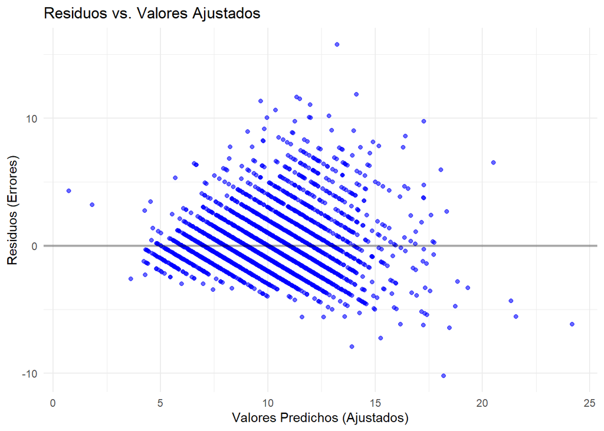

```r
datos_diagnostico <- data.frame(
  Ajustados = predict(modelo_segun_lasso),
  Residuos = residuals(modelo_segun_lasso)
)

ggplot(datos_diagnostico, aes(x = Ajustados, y = Residuos)) +
  geom_point(color = "blue", alpha = 0.6) +
  geom_hline(yintercept = 0, size = 1, alpha = 0.3) +
  labs(
    title = "Residuos vs. Valores Ajustados",
    x = "Valores Predichos (Ajustados)",
    y = "Residuos (Errores)"
  ) +
  theme_minimal()
```

### Diagnóstico de Normalidad

Analizamos la distribución de los residuos studentizados mediante un histograma y un gráfico de cuantiles teóricos (QQ-Plot).

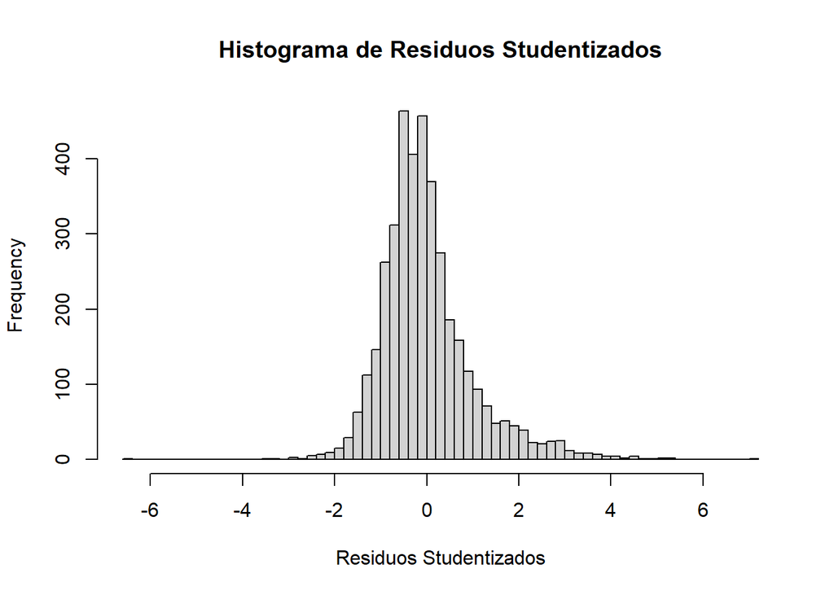

```r
st <- rstudent(modelo_segun_lasso)

# Histograma de residuos studentizados
hist(st, breaks = 62, main = "Histograma de Residuos Studentizados",
     xlab = "Residuos Studentizados", col = "lightgray")
```

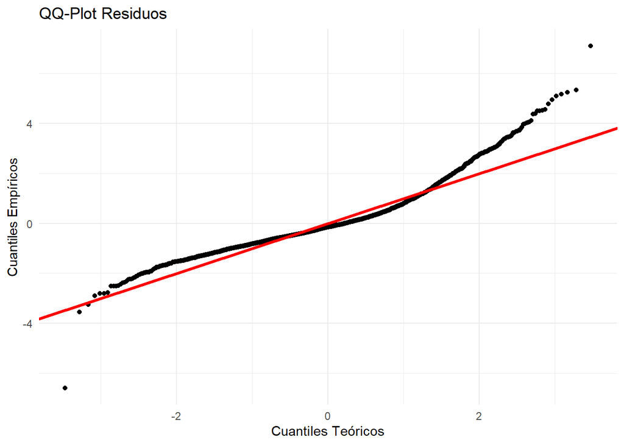

```r
# Construcción manual del QQ-Plot Normal
n <- nrow(data)
teo <- qnorm(seq(n) / (n + 1))
qq <- data.frame(teoricos = teo, empiricos = sort(st))

ggplot(qq, aes(x = teoricos, y = empiricos)) +
  geom_point() +
  labs(x = "Cuantiles Teóricos", y = "Cuantiles Empíricos", title = "QQ-Plot Residuos") +
  geom_abline(slope = 1, intercept = 0, col = "red", size = 1.2) +
  theme_minimal()
```

```r
# Test de formalización de normalidad
shapiro.test(st)
```

```
##
##  Shapiro-Wilk normality test
##
## data:  st
## W = 0.91815, p-value < 2.2e-16
```

### Identificación y Remoción Iterativa de Datos Influyentes (Distancia de Cook)

Dado el alejamiento de las colas en el gráfico de normalidad y para estabilizar el modelo, evaluamos la distancia de Cook ($D_i$) para remover de forma secuencial aquellas observaciones que alteran desproporcionadamente la estimación de los parámetros.

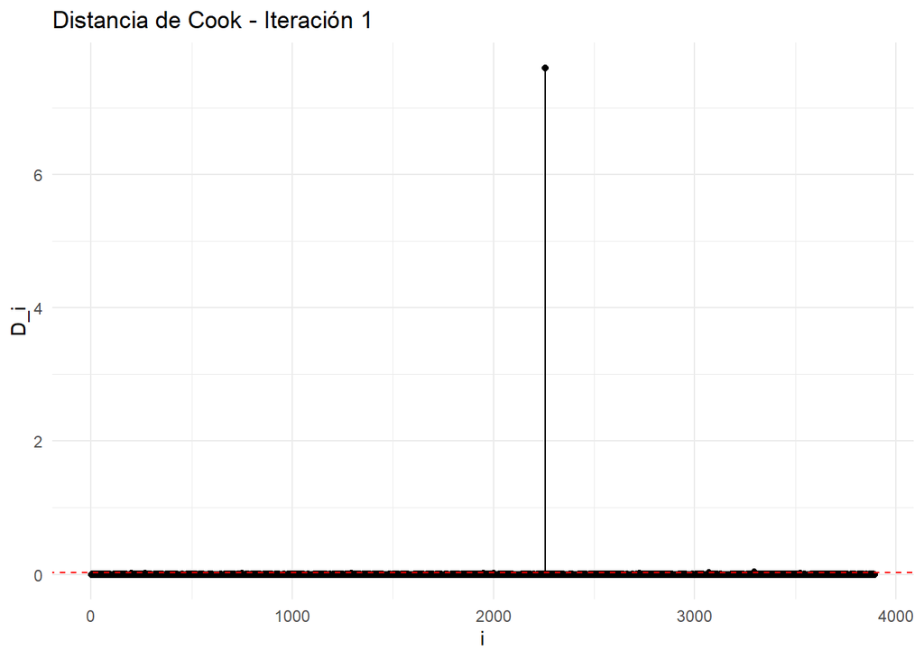

```r
data2 <- data
umbral_cook <- 0.022

# --- Iteración 1 ---
data2$D_i <- cooks.distance(modelo_segun_lasso)
data2$i   <- seq(nrow(data2))
idx_out1  <- which.max(data2$D_i)

# Gráfico Cook 1
ggplot(data2, aes(x = i, y = D_i)) +
  geom_point() +
  geom_segment(aes(x = i, xend = i, y = 0, yend = D_i)) +
  geom_abline(slope = 0, intercept = umbral_cook, col = "red", linetype = "dashed") +
  labs(title = "Distancia de Cook - Iteración 1", y = "D_i") +
  theme_minimal()
```

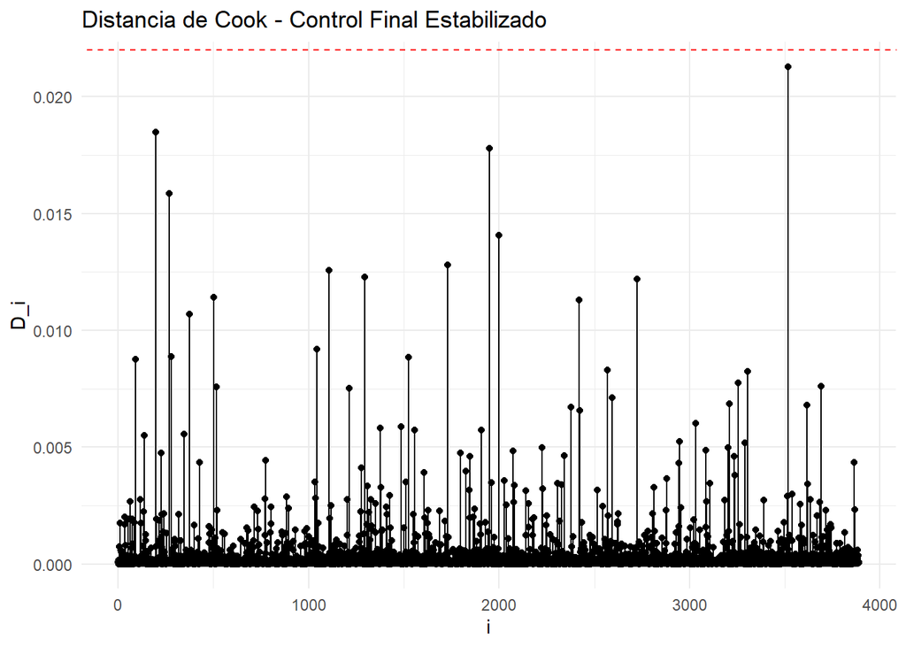

```r
# Remoción de la primera observación influyente
data2 <- data2[-idx_out1, ]

# --- Iteración 2 ---
modelo_sin_outliers <- lm(Age ~ Sex.Det + Height + Shucked.Weight + Shell.Weight + Diameter, data = data2)
data2$D_i <- cooks.distance(modelo_sin_outliers)
data2$i   <- seq(nrow(data2))
idx_out2  <- which.max(data2$D_i)

data2 <- data2[-idx_out2, ]

# --- Iteración 3 ---
modelo_sin_outliers <- lm(Age ~ Sex.Det + Height + Shucked.Weight + Shell.Weight + Diameter, data = data2)
data2$D_i <- cooks.distance(modelo_sin_outliers)
data2$i   <- seq(nrow(data2))
idx_out3  <- which.max(data2$D_i)

data2 <- data2[-idx_out3, ]

# --- Iteración 4 ---
modelo_sin_outliers <- lm(Age ~ Sex.Det + Height + Shucked.Weight + Shell.Weight + Diameter, data = data2)
data2$D_i <- cooks.distance(modelo_sin_outliers)
data2$i   <- seq(nrow(data2))
idx_out4  <- which.max(data2$D_i)

data2 <- data2[-idx_out4, ]

# --- Iteración 5 (Modelo Filtrado Final) ---
modelo_sin_outliers <- lm(Age ~ Sex.Det + Height + Shucked.Weight + Shell.Weight + Diameter, data = data2)
data2$D_i <- cooks.distance(modelo_sin_outliers)
data2$i   <- seq(nrow(data2))

ggplot(data2, aes(x = i, y = D_i)) +
  geom_point() +
  geom_segment(aes(x = i, xend = i, y = 0, yend = D_i)) +
  geom_abline(slope = 0, intercept = umbral_cook, col = "red", linetype = "dashed") +
  labs(title = "Distancia de Cook - Control Final Estabilizado", y = "D_i") +
  theme_minimal()
```

### Comparación de Eficiencia (Efecto de la Remoción de Outliers)

Para evaluar la ganancia en eficiencia tras la eliminación iterativa de los datos influyentes, comparamos los errores estándar de los coeficientes y el error estándar de los residuos entre el modelo inicial seleccionado por Lasso y el modelo final estabilizado.

```r
# Extracción de errores estándar del modelo con outliers
se_inicial <- summary(modelo_segun_lasso)$coefficients[, "Std. Error"]

# Extracción de errores estándar del modelo final limpio
se_final <- summary(modelo_sin_outliers)$coefficients[, "Std. Error"]

# Crear una tabla comparativa de los errores estándar
tabla_eficiencia <- data.frame(
  SE_Inicial = se_inicial,
  SE_Final = se_final,
  Reduccion_Porcentual = ((se_inicial - se_final) / se_inicial) * 100
)

print(tabla_eficiencia)
```

```
##                SE_Inicial   SE_Final Reduccion_Porcentual
## (Intercept)    0.28025117 0.28319760            -1.051353
## Diameter       0.41363643 0.09348093            77.400219
## Sex.DetI       0.09402538 0.95477089          -915.439531
## Height         0.63474813 0.01374638            97.834357
## Shucked.Weight 0.01378585 0.02527345           -83.328916
## Shell.Weight   0.02391538 0.44148612         -1746.034177
```

```r
# Comparación del Error Estándar de los Residuos (RSE)
cat("RSE Modelo Inicial:", summary(modelo_segun_lasso)$sigma, "\n")
```

```
## RSE Modelo Inicial: 2.235686
```

```r
cat("RSE Modelo Final (Sin Outliers):", summary(modelo_sin_outliers)$sigma, "\n")
```

```
## RSE Modelo Final (Sin Outliers): 2.217893
```

### Re-evaluación del supuesto de Normalidad y Linealidad

Evaluamos el impacto de la remoción de los datos influyentes sobre el diagnóstico de normalidad de los residuos y revisamos el comportamiento de la linealidad mediante los gráficos de residuos componentes (crPlots).

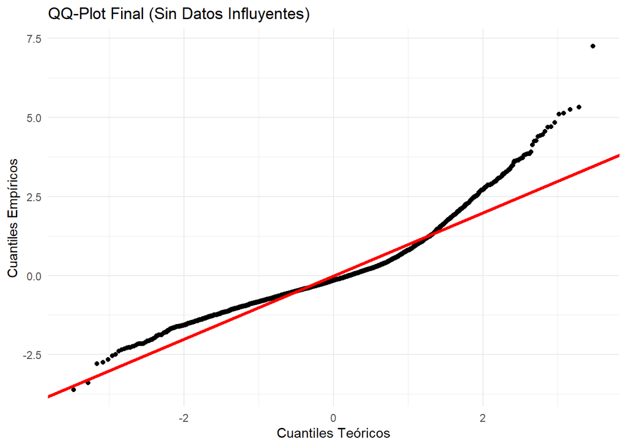

```r
st_final <- rstudent(modelo_sin_outliers)
n_final  <- nrow(data2)
teo_final <- qnorm(seq(n_final) / (n_final + 1))
qq_final  <- data.frame(teoricos = teo_final, empiricos = sort(st_final))

ggplot(qq_final, aes(x = teoricos, y = empiricos)) +
  geom_point() +
  labs(x = "Cuantiles Teóricos", y = "Cuantiles Empíricos", title = "QQ-Plot Final (Sin Datos Influyentes)") +
  geom_abline(slope = 1, intercept = 0, col = "red", size = 1.2) +
  theme_minimal()
```

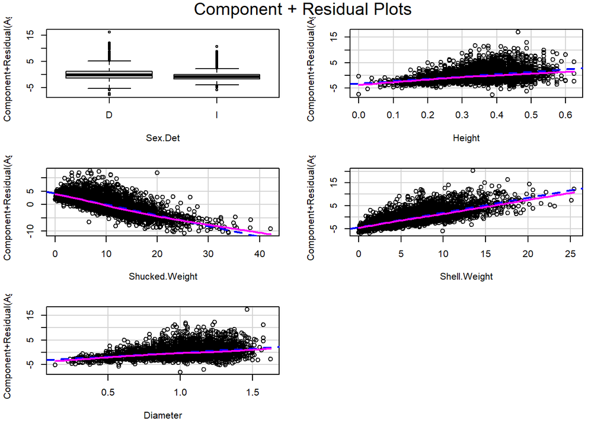

```r
# Evaluación de linealidad
crPlots(modelo_sin_outliers)
```

## 5. Evaluación del desempeño predictivo

Para evaluar la capacidad predictiva del modelo de forma rigurosa y sin recurrir al estadístico $R^2$, implementamos un esquema de validación dividiendo de manera aleatoria el conjunto de datos filtrado (`data2`) en un grupo de entrenamiento ($80\%$) y un grupo de prueba ($20\%$). El modelo se entrena exclusivamente con el primer grupo, y el rendimiento se evalúa sobre el segundo, simulando cómo se comportaría ante datos nuevos en el mundo real.

```r
# Fijamos la semilla para asegurar la reproducibilidad de la división
set.seed(13)

# División del dataset (80% Train, 20% Test)
proporcional <- 0.80
tamano_train <- floor(proporcional * nrow(data2))
indices_train <- sample(seq_len(nrow(data2)), size = tamano_train)

train_set <- data2[indices_train, ]
test_set  <- data2[-indices_train, ]
```

### Ajuste, Predicción y Cálculo del Error (MSE)

Ajustamos el modelo seleccionado sobre el conjunto de entrenamiento y generamos las predicciones correspondientes tanto para el set de entrenamiento como para el de prueba. Para medir de forma cuantitativa el error de predicción, calculamos el Error Cuadrático Medio (MSE).

```r
# Ajuste del modelo sobre el conjunto de entrenamiento (80% de los datos)
mod_train <- lm(Age ~ Diameter + Sex.Det + Height + Shucked.Weight + Shell.Weight, data = train_set)

# Generación de predicciones para evaluar rendimiento (Corregido el ... por <-)
train_set$pred <- predict(mod_train, newdata = train_set)
test_set$pred  <- predict(mod_train, newdata = test_set)

# Cálculo del MSE (Media de los residuos al cuadrado)
mse_train <- mean((train_set$Age - train_set$pred)^2)
mse_test  <- mean((test_set$Age - test_set$pred)^2)

cat("MSE en el conjunto de Entrenamiento:", mse_train, "\n")
```

```
## MSE en el conjunto de Entrenamiento: 4.94687
```

```r
cat("MSE en el conjunto de Prueba (Datos Nuevos):", mse_test, "\n")
```

```
## MSE en el conjunto de Prueba (Datos Nuevos): 4.773216
```

### Evaluación Visual: Valores Reales vs. Predichos (Conjunto de Prueba)

Para verificar visualmente la calidad de las predicciones sobre datos que el modelo nunca vio durante su construcción, generamos el gráfico de valores reales frente a los predichos utilizando únicamente las observaciones del conjunto de Prueba (Test).

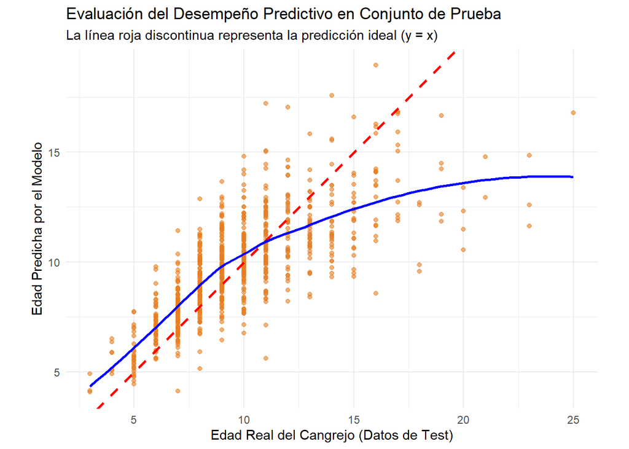

```r
# Gráfico de diagnóstico predictivo sobre el conjunto de test
ggplot(test_set, aes(x = Age, y = pred)) +
  geom_point(alpha = 0.6, color = "#e67e22") +
  geom_abline(intercept = 0, slope = 1, linetype = "dashed", color = "red", size = 1) +
  geom_smooth(method = "loess", color = "blue", se = FALSE) +
  labs(
    title = "Evaluación del Desempeño Predictivo en Conjunto de Prueba",
    subtitle = "La línea roja discontinua representa la predicción ideal (y = x)",
    x = "Edad Real del Cangrejo (Datos de Test)",
    y = "Edad Predicha por el Modelo"
  ) +
  theme_minimal() +
  coord_equal()
```

### Alternativa de Ajuste: Transformación Logarítmica

Como estrategia alternativa para intentar mejorar la capacidad de generalización del modelo, evaluamos el desempeño predictivo aplicando una transformación logarítmica sobre la variable respuesta en el entrenamiento, y luego recalculamos el error volviendo a la escala original de los datos (años).

```r
# Ajuste del modelo logarítmico en el grupo de entrenamiento
mod_log_train <- lm(log(Age) ~ Diameter + Sex.Det + Height + Shucked.Weight + Shell.Weight, data = train_set)

# Predicción en el grupo de prueba y retorno inmediato a la escala original (exponencial)
pred_log_test <- exp(predict(mod_log_train, newdata = test_set))

# MSE del modelo logarítmico en la escala original de la edad
mse_test_log <- mean((test_set$Age - pred_log_test)^2)
cat("MSE en Test empleando transformación logarítmica:", mse_test_log, "\n")
```

```
## MSE en Test empleando transformación logarítmica: 5.035879
```

Posteriormente, para verificar visualmente la calidad de las predicciones sobre datos que el modelo nunca vio durante su construcción, generamos el gráfico de valores reales frente a los predichos utilizando únicamente las observaciones del conjunto de Prueba (Test).

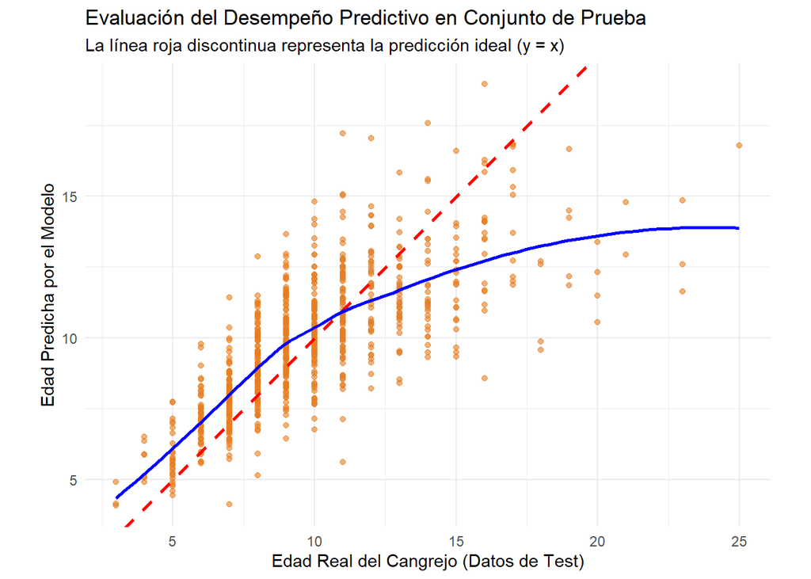

```r
# Gráfico de diagnóstico predictivo sobre el conjunto de test
ggplot(test_set, aes(x = Age, y = pred)) +
  geom_point(alpha = 0.6, color = "#e67e22") +
  geom_abline(intercept = 0, slope = 1, linetype = "dashed", color = "red", size = 1) +
  geom_smooth(method = "loess", color = "blue", se = FALSE) +
  labs(
    title = "Evaluación del Desempeño Predictivo en Conjunto de Prueba",
    subtitle = "La línea roja discontinua representa la predicción ideal (y = x)",
    x = "Edad Real del Cangrejo (Datos de Test)",
    y = "Edad Predicha por el Modelo"
  ) +
  theme_minimal() +
  coord_equal()
```

### Alternativa de Ajuste: Transformación Logarítmica

Como estrategia alternativa para intentar mejorar la capacidad de generalización del modelo, evaluamos el desempeño predictivo aplicando una transformación logarítmica sobre la variable respuesta en el entrenamiento, y luego recalculamos el error volviendo a la escala original de los datos (años).

```r
# Ajuste del modelo logarítmico en el grupo de entrenamiento
mod_log_train <- lm(log(Age) ~ Diameter + Sex.Det + Height + Shucked.Weight + Shell.Weight, data = train_set)

# Predicción en el grupo de prueba y retorno inmediato a la escala original (exponencial)
pred_log_test <- exp(predict(mod_log_train, newdata = test_set))

# MSE del modelo logarítmico en la escala original de la edad
mse_test_log <- mean((test_set$Age - pred_log_test)^2)
cat("MSE en Test empleando transformación logarítmica:", mse_test_log, "\n")
```

```
## MSE en Test empleando transformación logarítmica: 5.035879
```